# 4545 Team League: Season 17

[figure not shown]

### Overview

This [season’s](https://www.lichess4545.com/team4545/season/17/summary/) games were played between 13 May 2019 and 8 July 2019.

277 players participated, 77 (28%) of whom were new to the league.

28 teams played 112 matches over the season’s eight weeks. 14 matches (12%) were drawn, and 29 (26%) were won by just a single point.

In all, 814 games were played over the season. The season’s ‘unplayed pairing’ rate was 9.2%.[^1]

White won 348 games (42.5%), 125 games (15.3%) were drawn, and Black won 301 games (36.8%). The right-hand chart shows game results by colour for each board or average rating band.[^2]

[figure not shown]

### Final standings

*Team rosters ordered by number of games played (shown in brackets)*

1st place

[Smother of Dragons](https://www.lichess4545.com/team4545/season/17/team/15/)

2nd place

[Knights to Mate You](https://www.lichess4545.com/team4545/season/17/team/20/)

3rd place

[The Knight King](https://www.lichess4545.com/team4545/season/17/team/22/)

| Gold | Silver | Bronze |
| --- | --- | --- |
| lapetitemort (9) | Kraaft (8) | colwem (8) |
| f1nn33 (8) | UpGoerFive (8) | ErinYu (8) |
| kajoM (7) | badplayer_CM (7) | jmcginty15 (8) |
| matrix47 (7) | Forhavu (7) | momor (8) |
| RelativeImpact (7) | glbert (7) | mathijshuis (7) |
| sgis (7) | phantom567459 (7) | TCGRIF (6) |
| Tsatsa64 (7) | somethingpretentious (7) | toni4127 (6) |
| roso97 (6) | weits (6) | bward10 (5) |
| RandomiteTandomite0 (1) | cvillian (2) | Fudly (3) |
| rsava (1) | UnLuckyNiko (1) | Kvltvr_Wvltvr (1) |

[output cut: 3 more lines]

#### How the title race played out

[figure not shown]

**Match stories**

See the twists and turns in every match this season through these PDF visualisations…assuming they’ve already been created and uploaded. [Source script](https://github.com/rahulan-c/lichess4545-stats/blob/main/scripts/plot_match_story.R).

Round 1 | Round 2 | Round 3 | Round 4 | Round 5 | Round 6 | Round 7 | Round 8

### Top players 🎩

#### Board medals

Here are the top player performances on each board (minimum 5 games played).[^3]

| Board | Player(s) | Games | Points | Board Perf. |
| --- | --- | --- | --- | --- |
| 1 | Assassin_in_White | 6 | 6 | 3033.83333333333 |
| 1 | ChristopherChabris | 6 | 5 | 2418 |
| 1 | lovlas | 8 | 6.5 | 2378.5 |
| 2 | shakaali | 6 | 4 | 2115 |
| 2 | okei | 7 | 4.5 | 2109.71428571429 |
| 2 | BigEvo8 | 8 | 5.5 | 2109.25 |
| 3 | Tactix47 | 5 | 4.5 | 2258.4 |
| 3 | xobeci | 7 | 6 | 2224.57142857143 |
| 3 | Mahmut69 | 7 | 5 | 2053.85714285714 |
| 4 | matrix47 | 5 | 5 | 2634 |

[output cut: 14 more lines]

#### Best scorers

Here’s everyone who achieved a plus score of +5 or higher this season[^4]:

**Assassin_in_White** (6/6), **overlxrd** (6.5/7), **pepepibote** (7/8), **Tactix47** (6.5/7), **GoropadniPoni** (6.5/8), **leo2dipikke** (6.5/8), **lovlas** (6.5/8), **LucaGaglia73** (6.5/8), **matrix47** (6/7), **weits** (5.5/6), **xobeci** (6/7)

Players with plus scores of +6 or better get the **Ace** award.

### Stats - overview

#### Timing 📊

[figure not shown]

#### Length 📊

[figure not shown]

#### Most moves

*Includes games ranked at or above the 90th percentile by number of moves.*

| Rank | Players / Link | Date | Moves |
| --- | --- | --- | --- |
| 1 | Pedropablo72 - Rolihlahla | Sat 6 Jul 2019 | 104 |
| 2 | bward10 - ubique29 | Tue 4 Jun 2019 | 102 |
| 3 | JohnJPershing - jmcampbell | Sun 19 May 2019 | 95 |
| 4 | cerulean - Razorneck | Sun 2 Jun 2019 | 86 |
| 5 | BigEvo8 - jg777 | Sun 16 Jun 2019 | 85 |
| 6 | solidplayerr - rampichino | Wed 12 Jun 2019 | 84 |
| 7 | Itzal - okei | Thu 23 May 2019 | 82 |
| 8 | Sesquipedalism - K0stasP | Wed 12 Jun 2019 | 81 |
| 9 | glbert - Kalandra | Sat 29 Jun 2019 | 80 |
| 10 | Calcium237 - DMSA_OR | Sat 15 Jun 2019 | 79 |

[output cut: 78 more lines]

#### Longest games

*Includes games ranked at or above the 90th percentile by total clock time.*[^5]

| Rank | Players / Link | Date | Total time |
| --- | --- | --- | --- |
| 1 | bward10 - ubique29 | Tue 4 Jun 2019 | 3h 40m 18s |
| 2 | Pedropablo72 - Rolihlahla | Sat 6 Jul 2019 | 3h 29m 46s |
| 3 | cerulean - Razorneck | Sun 2 Jun 2019 | 3h 26m 10s |
| 4 | Sesquipedalism - K0stasP | Wed 12 Jun 2019 | 3h 18m 25s |
| 5 | Calcium237 - DMSA_OR | Sat 15 Jun 2019 | 3h 15m 40s |
| 6 | JohnJPershing - jmcampbell | Sun 19 May 2019 | 3h 14m 44s |
| 7 | arbisto - GGrkinic | Thu 4 Jul 2019 | 3h 11m 51s |
| 8 | H0tblackDesiat0 - slamjam | Fri 28 Jun 2019 | 3h 9m 29s |
| 9 | Skims - eie24 | Sun 7 Jul 2019 | 3h 4m 49s |
| 10 | swandog - cristoper | Wed 12 Jun 2019 | 3h 4m 22s |

[output cut: 78 more lines]

### Stats - by board/rating

#### ACPL and blunder rate 📊

[figure not shown]

#### Lowest combined ACPL

The games with the lowest combined ACPL (including draws).

| Board | Players / Link | Result | Sum ACPL | Date |
| --- | --- | --- | --- | --- |
| 1 | Prof_Moriarty - GoropadniPoni | 1/2-1/2 | 0 | Wed 19 Jun 2019 |
| 2 | Itzal - okei | 1/2-1/2 | 12 | Thu 23 May 2019 |
| 3 | xobeci - JonathanCoffin | 1/2-1/2 | 13 | Thu 16 May 2019 |
| 4 | mathijshuis - ed84 | 1-0 | 32 | Fri 24 May 2019 |
| 5 | Lethgo - jmcampbell | 1/2-1/2 | 28 | Sat 8 Jun 2019 |
| 5 | CarlosMagnussen - Calcium237 | 1/2-1/2 | 28 | Sun 7 Jul 2019 |
| 6 | mmb4854 - adande1 | 1/2-1/2 | 27 | Sat 25 May 2019 |
| 7 | Fritzmann - Numberman768 | 1/2-1/2 | 31 | Wed 5 Jun 2019 |
| 8 | asn8745 - Fudly | 0-1 | 38 | Fri 5 Jul 2019 |

#### Decisive games only

The *decisive* games with the lowest combined ACPL.

| Board | Players / Link | Result | Sum ACPL | Date |
| --- | --- | --- | --- | --- |
| 1 | IsaVulpes - FischyVishy | 1-0 | 31 | Thu 30 May 2019 |
| 2 | Razorneck - ChessPatzerSwan | 1-0 | 24 | Sun 26 May 2019 |
| 3 | BlackCat700 - Isachess | 1-0 | 42 | Tue 11 Jun 2019 |
| 4 | mathijshuis - ed84 | 1-0 | 32 | Fri 24 May 2019 |
| 5 | rampichino - Calcium237 | 1-0 | 38 | Thu 16 May 2019 |
| 6 | Rolihlahla - halloway | 1-0 | 35 | Wed 15 May 2019 |
| 7 | slamjam - momor | 1-0 | 34 | Fri 21 Jun 2019 |
| 8 | asn8745 - Fudly | 0-1 | 38 | Fri 5 Jul 2019 |

### Openings

#### First moves 📊

[figure not shown]

#### Top openings

All openings played in the season, excluding variations.

| rank | opening.broad | games | perc_w | white_wins | draws | black_wins | mean_eval_after_15 | mean_rating |
| --- | --- | --- | --- | --- | --- | --- | --- | --- |
| 1 | Sicilian Defense | 156 | 54.4871794871795 | 42.9487179487179 | 23.0769230769231 | 33.974358974359 | 0.464733333333333 | 1825.23397435897 |
| 2 | French Defense | 74 | 47.2972972972973 | 43.2432432432432 | 8.10810810810811 | 48.6486486486487 | 0.183561643835616 | 1761.02027027027 |
| 3 | Caro-Kann Defense | 52 | 55.7692307692308 | 50 | 11.5384615384615 | 38.4615384615385 | 0.596346153846154 | 1783.38461538462 |
| 4 | English Opening | 44 | 61.3636363636364 | 52.2727272727273 | 18.1818181818182 | 29.5454545454545 | 0.0452272727272727 | 1818.82954545455 |
| 5 | Ruy Lopez | 37 | 54.0540540540541 | 43.2432432432432 | 21.6216216216216 | 35.1351351351351 | 0.622285714285714 | 1748.2972972973 |
| 6 | Queen's Gambit Declined | 35 | 60 | 57.1428571428571 | 5.71428571428571 | 37.1428571428571 | 1.08771428571429 | 1800.37142857143 |
| 6 | Queen's Pawn Game | 35 | 37.1428571428571 | 25.7142857142857 | 22.8571428571429 | 51.4285714285714 | -0.665882352941176 | 1745.15714285714 |
| 7 | Indian Defense | 32 | 54.6875 | 46.875 | 15.625 | 37.5 | 0.475666666666667 | 1800.234375 |
| 7 | Italian Game | 32 | 59.375 | 50 | 18.75 | 31.25 | 0.504666666666667 | 1763.859375 |
| 8 | King's Indian Defense | 31 | 38.7096774193548 | 32.258064516129 | 12.9032258064516 | 54.8387096774194 | 0.305483870967742 | 1782.43548387097 |

[output cut: 53 more lines]

#### Best for White

White’s top-scoring openings, excluding variations. *Minimum 10 games played.*

| rank | opening.broad | games | perc_w | white_wins | draws | black_wins | mean_eval_after_15 | mean_rating |
| --- | --- | --- | --- | --- | --- | --- | --- | --- |
| 1 | Rapport-Jobava System | 11 | 72.7272727272727 | 72.7272727272727 | 0 | 27.2727272727273 | 0.277272727272727 | 1791.31818181818 |
| 2 | Slav Defense | 17 | 70.5882352941177 | 70.5882352941177 | 0 | 29.4117647058824 | 1.50470588235294 | 1790.14705882353 |
| 3 | Four Knights Game | 14 | 64.2857142857143 | 42.8571428571429 | 42.8571428571429 | 14.2857142857143 | 1.67384615384615 | 1853.57142857143 |
| 4 | English Opening | 44 | 61.3636363636364 | 52.2727272727273 | 18.1818181818182 | 29.5454545454545 | 0.0452272727272727 | 1818.82954545455 |
| 5 | Queen's Gambit Declined | 35 | 60 | 57.1428571428571 | 5.71428571428571 | 37.1428571428571 | 1.08771428571429 | 1800.37142857143 |
| 6 | Italian Game | 32 | 59.375 | 50 | 18.75 | 31.25 | 0.504666666666667 | 1763.859375 |
| 7 | Semi-Slav Defense | 16 | 56.25 | 56.25 | 0 | 43.75 | 0.41875 | 1875.875 |
| 8 | Caro-Kann Defense | 52 | 55.7692307692308 | 50 | 11.5384615384615 | 38.4615384615385 | 0.596346153846154 | 1783.38461538462 |
| 9 | Indian Defense | 32 | 54.6875 | 46.875 | 15.625 | 37.5 | 0.475666666666667 | 1800.234375 |
| 10 | Sicilian Defense | 156 | 54.4871794871795 | 42.9487179487179 | 23.0769230769231 | 33.974358974359 | 0.464733333333333 | 1825.23397435897 |

[output cut: 9 more lines]

#### Best for Black

Black’s top-scoring openings, excluding variations. *Minimum 10 games played.*

| rank | opening.broad | games | perc_b | black_wins | draws | white_wins | mean_eval_after_15 | mean_rating |
| --- | --- | --- | --- | --- | --- | --- | --- | --- |
| 1 | Pirc Defense | 11 | 77.2727272727273 | 72.7272727272727 | 9.09090909090909 | 18.1818181818182 | -1.43454545454545 | 1690.18181818182 |
| 2 | Queen's Pawn Game | 35 | 62.8571428571429 | 51.4285714285714 | 22.8571428571429 | 25.7142857142857 | -0.665882352941176 | 1745.15714285714 |
| 3 | King's Indian Defense | 31 | 61.2903225806452 | 54.8387096774194 | 12.9032258064516 | 32.258064516129 | 0.305483870967742 | 1782.43548387097 |
| 4 | Dutch Defense | 16 | 59.375 | 50 | 18.75 | 31.25 | 0.132857142857143 | 1886.875 |
| 5 | Nimzo-Indian Defense | 22 | 59.0909090909091 | 50 | 18.1818181818182 | 31.8181818181818 | -0.222272727272727 | 1897.84090909091 |
| 6 | Scotch Game | 21 | 57.1428571428571 | 52.3809523809524 | 9.52380952380952 | 38.0952380952381 | 1.60555555555556 | 1703.78571428571 |
| 7 | Scandinavian Defense | 20 | 55 | 45 | 20 | 35 | 0.3425 | 1766.8 |
| 8 | French Defense | 74 | 52.7027027027027 | 48.6486486486487 | 8.10810810810811 | 43.2432432432432 | 0.183561643835616 | 1761.02027027027 |
| 9 | Ruy Lopez | 37 | 45.945945945946 | 35.1351351351351 | 21.6216216216216 | 43.2432432432432 | 0.622285714285714 | 1748.2972972973 |
| 10 | Sicilian Defense | 156 | 45.5128205128205 | 33.974358974359 | 23.0769230769231 | 42.9487179487179 | 0.464733333333333 | 1825.23397435897 |

[output cut: 9 more lines]

#### Top gambits

The most played gambits over the season.[^6]

| Rank | Name | Games | White score (%) |
| --- | --- | --- | --- |
| 1 | Smith-Morra Gambit | 7 | 0.571428571428571 |
| 2 | Scotch Gambit | 5 | 0.5 |
| 3 | Benko Gambit | 4 | 0.375 |
| 4 | Anti-Moscow Gambit | 3 | 0.666666666666667 |
| 4 | Evans Gambit | 3 | 0.666666666666667 |
| 4 | Queen's Gambit Accepted | 3 | 0.666666666666667 |
| 5 | Ruy Lopez: Marshall Attack | 3 | 0.5 |
| 6 | Milner-Barry Gambit | 3 | 0.333333333333333 |
| 7 | Alekhine Gambit | 2 | 1 |
| 8 | Budapest Defense | 2 | 0.75 |

[output cut: 19 more lines]

#### Gambiteers 🤺

The players who enjoyed the most success when playing gambits.[^7] *Includes everyone who scored at least 50 per cent across at least two gambit games.*

| Rank | Player | Games | % Score | W | B | Choices |
| --- | --- | --- | --- | --- | --- | --- |
| 1 | jwwells42 | 4 | 50 | 3 | 1 | Smith-Morra Gambit, Blackmar-Diemer Gambit, Scotch Gambit, Ruy Lopez: Marshall Attack |
| 2 | BlackCat700 | 2 | 100 | 1 | 1 | Budapest Defense, Alekhine Gambit |
| 3 | FairyTaleTime | 2 | 75 | 1 | 1 | Ruy Lopez: Marshall Attack, Queen's Gambit |
| 4 | david-innes | 2 | 50 | 2 | 0 | Smith-Morra Gambit, Salvio Gambit |
| 4 | escabeche | 2 | 50 | 2 | 0 | Queen's Gambit, Anti-Moscow Gambit |
| 4 | litlee | 2 | 50 | 0 | 2 | Latvian Gambit |
| 4 | rampichino | 2 | 50 | 2 | 0 | Greco Gambit, Milner-Barry Gambit |
| 4 | sebiz | 2 | 50 | 2 | 0 | Scotch Gambit |

### Openings sunburst 🌞

Click on the image below to see a sunburst plot of all openings played in the season.

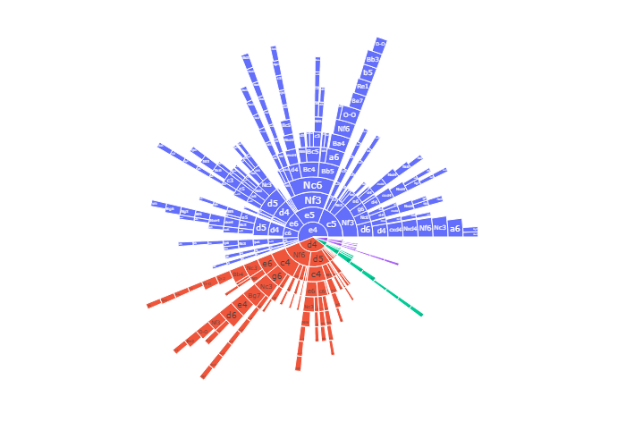

### Awards 🏆

Assorted awards to celebrate the season. See the footnote for more details about each award.[^8]

| Award | Name / Description | Winner(s) | Runner(s)-up |
| --- | --- | --- | --- |
| x | Aces | Assassin_in_White, overlxrd, pepepibote, Tactix47 |  |
| x | Archbishop of Accuracy | ChessPatzerSwan | Itzal, Sesquipedalism |
| x | Awesome Alt | Antaniserse, cvillian, Kvltvr_Wvltvr, Skims, tsnara, UnLuckyNiko | asian42, dkillian, endrawes0, Fudly, rsava, WildGooseChess (3) |
| x | Bullet Boss | NoNameK | Fritzmann, jessehf |
| x | David Award | kampsun | Mahmut69, matrix47 |
| x | Egalitarian Award | Endgame Spoilers |  |
| x | Gambit Guru | jwwells42 | BlackCat700, FairyTaleTime |
| x | Giri Award | jg777, michaeltallovsky, mmb4854, Razorneck |  |
| x | Grischuk's Cousin | seius | pepepibote, Kraaft |
| x | Houdini Award | Tactix47 | shakaali, Numberman768 |

[output cut: 10 more lines]

- Fortune favoured **Nd4**, who managed to win **3** matches by a single point!
- Conversely, **Endgame Spoilers** must be ruing their luck after suffering **3** agonising single-point defeats.

### Stats - tables 📚

Tons of detailed stats for your reading pleasure. All tables in this section are sortable and searchable - feel free to explore!

#### Team statistics

Check out various team stats in the table below. Hover over the abbreviated headers to see their full names.

| rank | Team | games | points | pts_nonforf | wins | draws | losses | players | avg_moves | ACPL | blunder_pc |
| --- | --- | --- | --- | --- | --- | --- | --- | --- | --- | --- | --- |
| 1 | Smother of Dragons | 63 | 37 | 34 | 31 | 6 | 26 | 13 | 38.5873015873016 | 46.5327025915261 | 4.44261620732209 |
| 2 | Knights to Mate You | 61 | 40 | 33.5 | 30 | 7 | 24 | 11 | 37.7704918032787 | 43.8289930555556 | 4.25347222222222 |
| 3 | The Knight King | 62 | 36.5 | 33 | 29 | 8 | 25 | 12 | 40.0806451612903 | 44.2752515090543 | 4.30583501006036 |
| 4 | Idiots Till Proven Otherwise | 59 | 35.5 | 31 | 25 | 12 | 22 | 8 | 44.0677966101695 | 37.1746153846154 | 3.57692307692308 |
| 5 | Imagine Hyperaccelerated Dragons | 58 | 37.5 | 32.5 | 29 | 7 | 22 | 12 | 41.5 | 41.1636892397175 | 3.82218529289572 |
| 6 | We will rook you! | 60 | 36.5 | 34 | 27 | 14 | 19 | 14 | 41.6333333333333 | 40.1176941553243 | 4.16333066453163 |
| 7 | Lichess Lovers Rewind | 63 | 36 | 33.5 | 27 | 13 | 23 | 8 | 43.8571428571429 | 41.6022439377488 | 4.19833514296055 |
| 8 | v2ctorious | 60 | 34.5 | 31 | 28 | 6 | 26 | 9 | 41.8833333333333 | 41.9303621169916 | 3.97930760047752 |
| 9 | O-O-Oh no you didn't | 58 | 34.5 | 28.5 | 23 | 11 | 24 | 8 | 37.8103448275862 | 51.4601003191974 | 5.42635658914729 |
| 10 | Illogical Chess - Move by Move | 56 | 33 | 25.5 | 23 | 5 | 28 | 12 | 37.9464285714286 | 44.3562352941176 | 3.76470588235294 |

[output cut: 18 more lines]

#### Best performances / highest accuracy

##### Best relative performances

This table shows players’ *relative* performance ratings – that is, their performance rating over the season minus their initial rating before their first game.[^9] *Includes everyone with a positive relative performance rating over at least five games.*

| # | Player | Games | W | D | L | Initial | Perf | Diff. |
| --- | --- | --- | --- | --- | --- | --- | --- | --- |
| 1 | Assassin_in_White | 6 | 6 | 0 | 0 | 2365 | 3033.83333333333 | 668.833333333333 |
| 2 | overlxrd | 7 | 6 | 1 | 0 | 1534 | 2002.85714285714 | 468.857142857143 |
| 3 | Tactix47 | 7 | 6 | 1 | 0 | 1845 | 2295 | 450 |
| 4 | weits | 6 | 5 | 1 | 0 | 1801 | 2241 | 440 |
| 5 | xobeci | 7 | 5 | 2 | 0 | 1876 | 2224.57142857143 | 348.571428571428 |
| 6 | yvettenicole | 5 | 3 | 0 | 2 | 1209 | 1519.8 | 310.8 |
| 7 | Tsatsa64 | 6 | 5 | 0 | 1 | 1671 | 1976.83333333333 | 305.833333333333 |
| 8 | pepepibote | 8 | 7 | 0 | 1 | 1529 | 1815.5 | 286.5 |
| 9 | leo2dipikke | 8 | 6 | 1 | 1 | 1607 | 1881.75 | 274.75 |
| 10 | garfield1980 | 6 | 5 | 0 | 1 | 1819 | 2091 | 272 |

[output cut: 97 more lines]

##### Lowest ACPL

All players who played at least five games and achieved a season ACPL in the 20th percentile or below. Note that ‘season ACPL’ differs from Lichess game-wide ACPL figures, as it excludes opening moves as well as most moves played in objectively decided positions. See the footnote for full details.[^10] ACPLs based on Lichess’s published figures are provided for comparison purposes.

| Rank | Player | Games | Season ACPL | Lichess ACPL |
| --- | --- | --- | --- | --- |
| 1 | ChessPatzerSwan | 5 | 22.5354330708661 | 29.0871369294606 |
| 2 | Itzal | 8 | 29.0108695652174 | 25.9119170984456 |
| 3 | Sesquipedalism | 6 | 29.3815028901734 | 28.2214765100671 |
| 4 | IsaVulpes | 8 | 30.2231404958678 | 22.1755102040816 |
| 5 | alms | 7 | 32.0089285714286 | 22.3152866242038 |
| 6 | Assassin_in_White | 6 | 32.8073394495413 | 29.2518518518519 |
| 7 | Okoros | 8 | 34.9294117647059 | 28.3582554517134 |
| 8 | RaitonvsFuuton | 7 | 36.4065040650407 | 28.5371621621622 |
| 9 | lovlas | 8 | 37.2624113475177 | 28.3009404388715 |
| 10 | ErinYu | 8 | 37.6186046511628 | 31.4343163538874 |

[output cut: 30 more lines]

#### Time spent / strongest opponents

##### Time spent

The 50 players who spent the most clock time over the season.

| Rank | Player | Games | Total time spent |
| --- | --- | --- | --- |
| 1 | NoNameK | 8 | 10h 32m 3s |
| 2 | Grzybozbur | 8 | 10h 15m 49s |
| 3 | Finneri | 8 | 9h 59m 40s |
| 4 | Pedropablo72 | 11 | 9h 44m 52s |
| 5 | jessehf | 8 | 9h 14m 8s |
| 6 | k-night-moves | 8 | 9h 8m 47s |
| 7 | Kraaft | 8 | 9h 5m 47s |
| 8 | adande1 | 9 | 9h 5m 5s |
| 9 | mmb4854 | 8 | 9h 3m 14s |
| 10 | arbisto | 8 | 8h 52m 48s |

[output cut: 40 more lines]

##### Time spent per move (after move 10)

Minimum 3 games played.

| Rank | Player | Games | Moves | Time spent per move | Percentile |
| --- | --- | --- | --- | --- | --- |
| 1 | val1313 | 5 | 91 | 2m 35.8s | 100 |
| 2 | lakinwecker | 5 | 65 | 2m 35.5s | 100 |
| 3 | jfarah | 5 | 93 | 2m 33.0s | 99 |
| 4 | michaeltallovsky | 7 | 159 | 2m 20.6s | 99 |
| 5 | WarGoblin | 3 | 64 | 2m 18.1s | 98 |
| 6 | f1nn33 | 8 | 179 | 2m 11.0s | 98 |
| 7 | AUroach | 8 | 214 | 2m 8.4s | 97 |
| 8 | Showboater | 3 | 90 | 2m 8.0s | 97 |
| 9 | yago666 | 8 | 164 | 2m 7.5s | 96 |
| 10 | mln8 | 3 | 98 | 2m 6.4s | 96 |

[output cut: 215 more lines]

##### Strength of schedule

The players who faced the best-scoring opponents over the season, when judged by their collective score over all their *other* games. *Suggested by Tranzoo.*

| # | Player | Opp Games | Opp Pts | Opp % |
| --- | --- | --- | --- | --- |
| 1 | kampsun | 20 | 14.5 | 72.5 |
| 2 | Mahmut69 | 41 | 29.5 | 71.9512195121951 |
| 3 | matrix47 | 39 | 28 | 71.7948717948718 |
| 4 | erv123 | 41 | 29 | 70.7317073170732 |
| 5 | Tranzoo | 27 | 18.5 | 68.5185185185185 |
| 6 | anopows | 36 | 24.5 | 68.0555555555556 |
| 7 | endrawes0 | 27 | 18 | 66.6666666666667 |
| 8 | pfntr | 34 | 22.5 | 66.1764705882353 |
| 9 | TCGRIF | 35 | 23 | 65.7142857142857 |
| 10 | paolone | 52 | 34 | 65.3846153846154 |

[output cut: 95 more lines]

#### Comebacks and upsets

##### Comebacks

The players who achieved the most significant comeback wins and draws over the season.[^11] *Suggested by Lou-E.*

| Rank | Player | CB Games | Wins from < -6 | Wins from < -3 | Draws from < -6 | Draws from < -3 |
| --- | --- | --- | --- | --- | --- | --- |
| 1 | Tactix47 | 5 | 3 | 2 | 0 | 0 |
| 2 | shakaali | 3 | 2 | 1 | 0 | 0 |
| 3 | Numberman768 | 3 | 1 | 2 | 0 | 0 |
| 3 | sivvaaa | 3 | 1 | 2 | 0 | 0 |
| 4 | escabeche | 3 | 1 | 1 | 0 | 1 |
| 4 | FracPhilo | 2 | 2 | 0 | 0 | 0 |
| 4 | lovlas | 3 | 1 | 1 | 0 | 1 |
| 4 | pepepibote | 2 | 2 | 0 | 0 | 0 |
| 4 | Reodor | 2 | 2 | 0 | 0 | 0 |
| 4 | Teachmetimes2 | 2 | 2 | 0 | 0 | 0 |

[output cut: 136 more lines]

##### Biggest upsets

Everyone who defeated an opponent who outrated them by at least 100 points.

| Rank | Player | Upset Margin | Link |
| --- | --- | --- | --- |
| 1 | gokuba | 327 | https://lichess.org/HnNTkFiA |
| 2 | yvettenicole | 289 | https://lichess.org/n20QSphO |
| 3 | jessehf | 210 | https://lichess.org/z2qefscO |
| 4 | yvettenicole | 206 | https://lichess.org/vA38BMe9 |
| 5 | yvettenicole | 202 | https://lichess.org/3vvwdAkz |
| 6 | FracPhilo | 195 | https://lichess.org/WCtp1DxQ |
| 7 | EmreA | 189 | https://lichess.org/nUZPIsEG |
| 8 | erv123 | 188 | https://lichess.org/VffnL6iG |
| 9 | FracPhilo | 172 | https://lichess.org/klNFydnQ |
| 10 | erv123 | 168 | https://lichess.org/nOAOa2JV |

[output cut: 21 more lines]

##### Repeated upsets

Everyone who achieved multiple wins over opponents rated at least 50 points higher.

| Rank | Player | Total Upset Margin | Upsets | Avg Upset Margin | Biggest Margin |
| --- | --- | --- | --- | --- | --- |
| 1 | yvettenicole | 697 | 3 | 232.333333333333 | 289 |
| 2 | FracPhilo | 532 | 3 | 177.333333333333 | 195 |
| 3 | jessehf | 370 | 2 | 185 | 210 |
| 4 | erv123 | 356 | 2 | 178 | 188 |
| 5 | EmreA | 290 | 2 | 145 | 189 |

#### Dawdlers and instant movers

##### Least time left after move 10

Players who had the least time left after only 10 moves…but still managed to win! *Suggested by Silkthewanderer.*

| Rank | Player | Time left after 10 moves | Link |
| --- | --- | --- | --- |
| 1 | seius | 8m 18s | https://lichess.org/orTEtGoz#19 |
| 2 | pepepibote | 14m 48s | https://lichess.org/1qnXVQHF#19 |
| 3 | Kraaft | 14m 49s | https://lichess.org/rRC9BCqu#19 |
| 4 | ChristopherChabris | 17m 55s | https://lichess.org/8CxWrAVV#19 |
| 5 | Finneri | 19m 27s | https://lichess.org/q7mQgKWs#20 |
| 6 | HighonPotnuse | 19m 38s | https://lichess.org/8oCSQI6o#19 |
| 7 | lovlas | 20m 1s | https://lichess.org/rIoIQqDj#20 |
| 8 | adande1 | 20m 36s | https://lichess.org/yc2MkTa6#20 |
| 9 | Footpath | 21m 16s | https://lichess.org/unomwaP8#20 |
| 10 | Assassin_in_White | 21m 33s | https://lichess.org/JK7IHnwj#19 |

##### Instant moves

Players who made at least five ‘instant’ moves (in under 0.5s), including pre-moves.

| Rank | Player | Instant moves |
| --- | --- | --- |
| 1 | NoNameK | 22 |
| 2 | Fritzmann | 21 |
| 3 | jessehf | 19 |
| 4 | xkv | 16 |
| 5 | jrvdwjr | 14 |
| 5 | Prof_Moriarty | 14 |
| 6 | glbert | 13 |
| 6 | Itzal | 13 |
| 6 | jg777 | 13 |
| 6 | jmcampbell | 13 |

[output cut: 49 more lines]

#### Longest thinks, time trouble addicts, and lucky escapes

##### Longest thinks

The longest times spent on a single move.

*Top 100 shown.*

| # | Player | Time spent | Colour | Move | Link |
| --- | --- | --- | --- | --- | --- |
| 1 | dean7777777 | 34m 1s | Black | 14 | https://lichess.org/EiyEt0ny#28 |
| 2 | RobUmbra | 31m 16s | Black | 14 | https://lichess.org/Ew6tZ3xn#28 |
| 3 | seius | 31m 7s | White | 7 | https://lichess.org/orTEtGoz#13 |
| 4 | mln8 | 30m 2s | White | 21 | https://lichess.org/a1e6Gy5g#41 |
| 5 | Kraaft | 26m 8s | White | 15 | https://lichess.org/iHUriSkh#29 |
| 6 | Kraaft | 24m 25s | White | 14 | https://lichess.org/gGqiz71V#27 |
| 7 | bufferunderrun | 24m 5s | White | 23 | https://lichess.org/ggaCrfrH#45 |
| 7 | SpeedCobra | 24m 5s | Black | 18 | https://lichess.org/tvYM7VHo#36 |
| 8 | GoropadniPoni | 22m 58s | White | 12 | https://lichess.org/VAJpAx77#23 |
| 9 | DMSA_OR | 22m 36s | Black | 14 | https://lichess.org/6S3kM4q9#28 |

[output cut: 90 more lines]

##### Time trouble addicts

Shows players by proportion of moves made in time trouble (defined as having less than a minute remaining on the clock). Includes everyone who played at least 100 moves over the season while making at least one move in time trouble.

| # | Player | All moves | With < 1min left | Time Trouble % |
| --- | --- | --- | --- | --- |
| 1 | Footpath | 221 | 82 | 0.3710407239819 |
| 2 | NoNameK | 391 | 142 | 0.363171355498721 |
| 3 | KN960 | 107 | 27 | 0.252336448598131 |
| 4 | Sleivert | 215 | 50 | 0.232558139534884 |
| 5 | seius | 231 | 51 | 0.220779220779221 |
| 6 | Grzybozbur | 386 | 77 | 0.199481865284974 |
| 7 | astralfenix | 278 | 54 | 0.194244604316547 |
| 8 | Sesquipedalism | 297 | 50 | 0.168350168350168 |
| 9 | mln8 | 127 | 19 | 0.149606299212598 |
| 10 | WildGooseChess | 132 | 19 | 0.143939393939394 |

[output cut: 92 more lines]

##### Saved by the bell

Players who made moves with under 5 seconds left on their clock…and still won![^12]

| Player | Moves with under 5s left | Least time left | Link |
| --- | --- | --- | --- |
| pepepibote | 1 | 1 | https://lichess.org/1qnXVQHF |
| k-night-moves | 1 | 2 | https://lichess.org/mbQGp6HZ |
| AUroach | 1 | 3 | https://lichess.org/OKUF5OFo |
| Rolihlahla | 1 | 4 | https://lichess.org/Af6ljwyl |
| astralfenix | 1 | 4 | https://lichess.org/POMSGA5S |
| Sesquipedalism | 1 | 5 | https://lichess.org/mOvje64e |

#### Misc. facts

##### Notable mates

All games in the season that ended in a notable checkmate pattern…that I can detect successfully 😄. That means this currently includes all Anastasia’s, Arabian, back rank, hook, and smothered mates. To see game details, open the image in a different tab or window. [Source script](https://github.com/rahulan-c/lichess4545-stats/blob/main/scripts/checkmate_patterns.py).

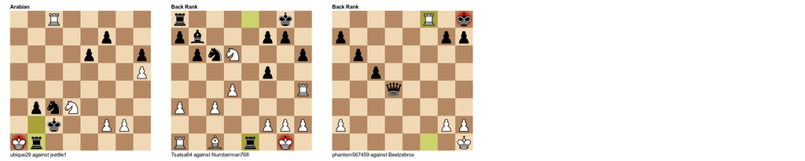